# Machine Learning Project

Luis Oña

2 de noviembre de 2018

```r
library(tidyverse)
library(caret)
library(e1071)
library(rpart)
library(rpart.plot)
library(RColorBrewer)
#library(rattle)
library(randomForest)
library(knitr)
```

## Introduction

### Background

Using devices such as Jawbone Up, Nike FuelBand, and Fitbit it is now possible to collect a large amount of data about personal activity relatively inexpensively. These type of devices are part of the quantified self movement - a group of enthusiasts who take measurements about themselves regularly to improve their health, to find patterns in their behavior, or because they are tech geeks. One thing that people regularly do is quantify how much of a particular activity they do, but they rarely quantify how well they do it. In this project, your goal will be to use data from accelerometers on the belt, forearm, arm, and dumbell of 6 participants. They were asked to perform barbell lifts correctly and incorrectly in 5 different ways. More information is available from the website here: http://groupware.les.inf.puc-rio.br/har (see the section on the Weight Lifting Exercise Dataset).

### Data

The training data for this project are available here: https://d396qusza40orc.cloudfront.net/predmachlearn/pml-training.csv

The test data are available here: https://d396qusza40orc.cloudfront.net/predmachlearn/pml-testing.csv

The data for this project come from this source: http://groupware.les.inf.puc-rio.br/har. If you use the document you create for this class for any purpose please cite them as they have been very generous in allowing their data to be used for this kind of assignment.

## Data load

```r
trainUrl <- "http://d396qusza40orc.cloudfront.net/predmachlearn/pml-training.csv"
testUrl <- "http://d396qusza40orc.cloudfront.net/predmachlearn/pml-testing.csv"

training <- read.csv(url(trainUrl), na.strings=c("NA", "#DIV/0!", ""))
testing <- read.csv(url(testUrl), na.strings=c("NA", "#DIV/0!", ""))

dim(testing)
```

```
## [1]  20 160
```

```r
dim(testing)
```

```
## [1]  20 160
```

## Cleaning the data

Remove variables that have one unique value (i.e. are zero variance predictors). Because don’t contribute information to the model.

```r
x <- apply(training, 2, function(x){length(unique(x))})
training <- training %>% select(which(x>1))
testing <- testing %>% select(which(x>1))
dim(training)
```

```
## [1] 19622   154
```

```r
dim(testing)
```

```
## [1]  20 154
```

Clean variables with much `NA's`

```r
x <- colSums(is.na(training))/nrow(training)
table(x)
```

```
## x
##                 0 0.979308938946081 0.979359902150647 0.979410865355213
##                60                67                 1                 1
## 0.979512791764346 0.979563754968912 0.979767607787178 0.979818570991744
##                 1                 4                 1                 4
##  0.97986953419631 0.980939761492203 0.983233105697686 0.983284068902253
##                 2                 2                 1                 1
## 0.983385995311385 0.983538884925084  0.98358984812965 0.983640811334217
##                 2                 1                 4                 2
```

There are a lot variables with `NA's`, we procedure to eliminate

```r
training <- training %>% select(which(x  == 0))
testing <- testing %>% select(which(x == 0))
dim(training)
```

```
## [1] 19622    60
```

```r
dim(testing)
```

```
## [1] 20 60
```

Eliminate the 3 first variables because are people information

```r
training <- training %>% select(-c(1:3))
```

Transform `cvtd_timestamp` variable (date) in a `month`

```r
training <- training %>%
    mutate(Month = as.factor(lubridate::month(lubridate::dmy_hms(cvtd_timestamp)))) %>%
    select(-cvtd_timestamp)
testing <- testing %>%
    mutate(Month = as.factor(lubridate::month(lubridate::dmy_hms(cvtd_timestamp)))) %>%
    select(-cvtd_timestamp)

summary(training$num_window)
```

```
##    Min. 1st Qu.  Median    Mean 3rd Qu.    Max.
##     1.0   222.0   424.0   430.6   644.0   864.0
```

We have a clean data frame for create a model.

```r
str(training)
```

```
## 'data.frame':    19622 obs. of  57 variables:
##  $ raw_timestamp_part_2: int  788290 808298 820366 120339 196328 304277 368296 440390 484323 484434 ...
##  $ new_window          : Factor w/ 2 levels "no","yes": 1 1 1 1 1 1 1 1 1 1 ...
##  $ num_window          : int  11 11 11 12 12 12 12 12 12 12 ...
##  $ roll_belt           : num  1.41 1.41 1.42 1.48 1.48 1.45 1.42 1.42 1.43 1.45 ...
##  $ pitch_belt          : num  8.07 8.07 8.07 8.05 8.07 8.06 8.09 8.13 8.16 8.17 ...
##  $ yaw_belt            : num  -94.4 -94.4 -94.4 -94.4 -94.4 -94.4 -94.4 -94.4 -94.4 -94.4 ...
##  $ total_accel_belt    : int  3 3 3 3 3 3 3 3 3 3 ...
##  $ gyros_belt_x        : num  0 0.02 0 0.02 0.02 0.02 0.02 0.02 0.02 0.03 ...
##  $ gyros_belt_y        : num  0 0 0 0 0.02 0 0 0 0 0 ...
##  $ gyros_belt_z        : num  -0.02 -0.02 -0.02 -0.03 -0.02 -0.02 -0.02 -0.02 -0.02 0 ...
##  $ accel_belt_x        : int  -21 -22 -20 -22 -21 -21 -22 -22 -20 -21 ...
##  $ accel_belt_y        : int  4 4 5 3 2 4 3 4 2 4 ...
##  $ accel_belt_z        : int  22 22 23 21 24 21 21 21 24 22 ...
##  $ magnet_belt_x       : int  -3 -7 -2 -6 -6 0 -4 -2 1 -3 ...
```

[output cut: 43 more lines]

## Train Modelo

### Target Variable

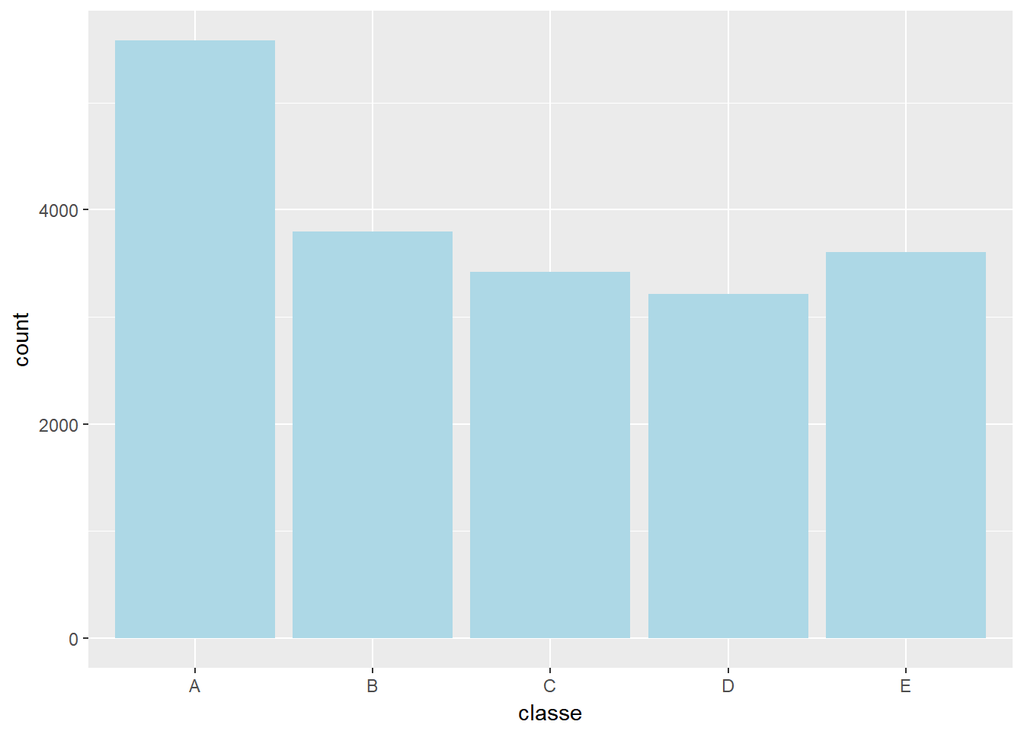

```r
ggplot(training, aes(classe))+
    geom_bar(fill="lightblue")
```

## Features Selection

We will create a Random Forest Model for feature Selection, because this model has a Importance Variables characteristic.

```r
rf_model <- randomForest(classe~., data = training, importance=TRUE)
var_import <- importance(rf_model) %>% as.data.frame() %>%
    mutate(Variable = row.names(.)) %>%
    arrange(desc(MeanDecreaseGini))
head(var_import, 10)
```

```
##           A        B        C        D        E MeanDecreaseAccuracy
## 1  35.33880 45.11400 53.49799 41.44382 41.65619             49.39788
## 2  36.93534 46.53664 39.69686 46.10388 38.85434             51.68228
## 3  39.74725 46.74268 41.67475 45.20806 32.02642             59.22375
## 4  30.96979 33.55170 37.33136 33.79592 31.65546             39.85190
## 5  40.16670 39.34954 44.45539 36.26969 33.01423             46.92963
## 6  29.52957 43.63933 37.49761 34.04413 32.20073             45.58515
## 7  31.29091 33.31754 41.81453 33.07657 29.75567             38.93747
## 8  26.11235 23.03118 29.56706 21.30472 21.93868             26.60632
## 9  23.73412 27.35209 30.58281 26.73494 23.47101             28.57412
## 10 21.29189 25.05669 24.13273 23.64402 20.29216             28.31900
##    MeanDecreaseGini          Variable
## 1         1390.6292        num_window
## 2         1086.8243         roll_belt
## 3          818.2952          yaw_belt
## 4          742.4922     pitch_forearm
## 5          684.2368 magnet_dumbbell_z
## 6          649.6452        pitch_belt
## 7          614.0825 magnet_dumbbell_y
## 8          524.3874      roll_forearm
## 9          477.4439 magnet_dumbbell_x
## 10         401.1172      accel_belt_z
```

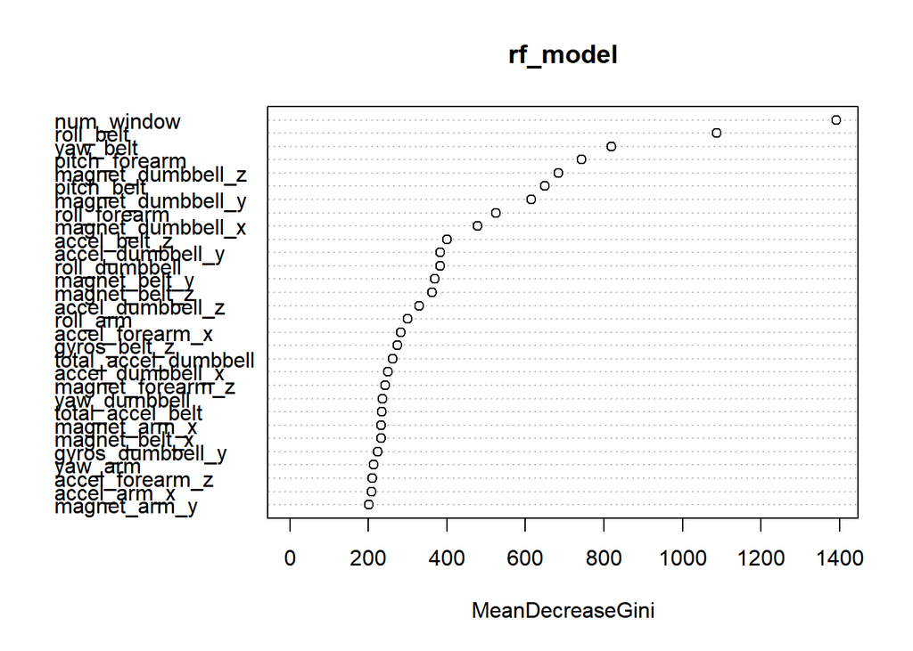

```r
varImpPlot(rf_model,type=2)
```

We can see that the first 8 variables are the most important (in the rf model) for classify `classe` variable. With these variables we are going to run a SVM model.

```r
var_model <- c(var_import$Variable[1:8], "classe")
training1 <- training %>% select(var_model)
#svm_model <- svm(classe~., data = training1)
tune <- tune(svm, classe~., data = training1,
                 ranges =list(cost=  10^(-1:2), gamma = c(.5,1,2)),
             tunecontrol=tune.control(cross=10))
summary(tune)
```

```
##
## Parameter tuning of 'svm':
##
## - sampling method: 10-fold cross validation
##
## - best parameters:
##  cost gamma
##   100     2
##
## - best performance: 0.004484778
##
## - Detailed performance results:
##     cost gamma       error   dispersion
## 1    0.1   0.5 0.197532434 0.0098936674
## 2    1.0   0.5 0.090612311 0.0066620954
## 3   10.0   0.5 0.042350015 0.0054131971
## 4  100.0   0.5 0.014626503 0.0011030708
## 5    0.1   1.0 0.158392935 0.0107726614
## 6    1.0   1.0 0.065334582 0.0060978534
## 7   10.0   1.0 0.024971790 0.0020781820
## 8  100.0   1.0 0.008969633 0.0022051113
## 9    0.1   2.0 0.115176406 0.0096315985
## 10   1.0   2.0 0.049994392 0.0049084375
## 11  10.0   2.0 0.016308174 0.0009896741
## 12 100.0   2.0 0.004484778 0.0013760914
```

```r
print(tune)
```

```
##
## Parameter tuning of 'svm':
##
## - sampling method: 10-fold cross validation
##
## - best parameters:
##  cost gamma
##   100     2
##
## - best performance: 0.004484778
```

We have the optimal hyperprameters, then we run a svm model with these

```r
svm_model <- svm(classe~., data = training1, cost=100, gamma=2 )
summary(svm_model)
```

```
##
## Call:
## svm(formula = classe ~ ., data = training1, cost = 100, gamma = 2)
##
##
## Parameters:
##    SVM-Type:  C-classification
##  SVM-Kernel:  radial
##        cost:  100
##       gamma:  2
##
## Number of Support Vectors:  2772
##
##  ( 423 737 506 584 522 )
##
##
## Number of Classes:  5
##
## Levels:
##  A B C D E
```

```r
confusionMatrix(svm_model$fitted, training1$classe)
```

```
## Confusion Matrix and Statistics
##
##           Reference
## Prediction    A    B    C    D    E
##          A 5578    1    0    0    0
##          B    2 3796    0    0    0
##          C    0    0 3409   13    0
##          D    0    0   13 3201    4
##          E    0    0    0    2 3603
##
## Overall Statistics
##
##                Accuracy : 0.9982
##                  95% CI : (0.9975, 0.9988)
##     No Information Rate : 0.2844
##     P-Value [Acc > NIR] : < 2.2e-16
##
##                   Kappa : 0.9977
##  Mcnemar's Test P-Value : NA
##
## Statistics by Class:
##
##                      Class: A Class: B Class: C Class: D Class: E
## Sensitivity            0.9996   0.9997   0.9962   0.9953   0.9989
## Specificity            0.9999   0.9999   0.9992   0.9990   0.9999
## Pos Pred Value         0.9998   0.9995   0.9962   0.9947   0.9994
## Neg Pred Value         0.9999   0.9999   0.9992   0.9991   0.9998
## Prevalence             0.2844   0.1935   0.1744   0.1639   0.1838
## Detection Rate         0.2843   0.1935   0.1737   0.1631   0.1836
## Detection Prevalence   0.2843   0.1936   0.1744   0.1640   0.1837
## Balanced Accuracy      0.9998   0.9998   0.9977   0.9971   0.9994
```

## Predicting Results on the Test Data

```r
pred <- predict(svm_model,testing)
table(pred)
```

```
## pred
## A B C D E
## 7 8 1 1 3
```

```r
pred
```

```
##  1  2  3  4  5  6  7  8  9 10 11 12 13 14 15 16 17 18 19 20
##  B  A  B  A  A  E  D  B  A  A  B  C  B  A  E  E  A  B  B  B
## Levels: A B C D E
```